# Внешний курс. Раздел 3.

Репкина Елизавета Андреевна

1132246753@rudn.ru

Российский университет дружбы народов

Информация

## Докладчик

- Репкина Елизавета Андреевна
- НКАбд-04-24

# Вводная часть

## Цели и задачи

Прохождение внешнего курса “Основы кибербезопасности”. Получение знаний в сфере кибербезопасности.

# Прохождение раздела

## 1

В ассиметричных криптографических примитивах обе стороны имеют пару ключей (рис. 1)

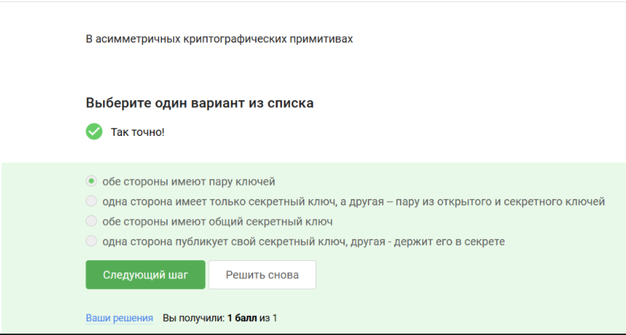

Рисунок 1: Задание 1

## 2

Криптографическая хэш-функция не обеспечивает конфиденциальность (рис. 2)

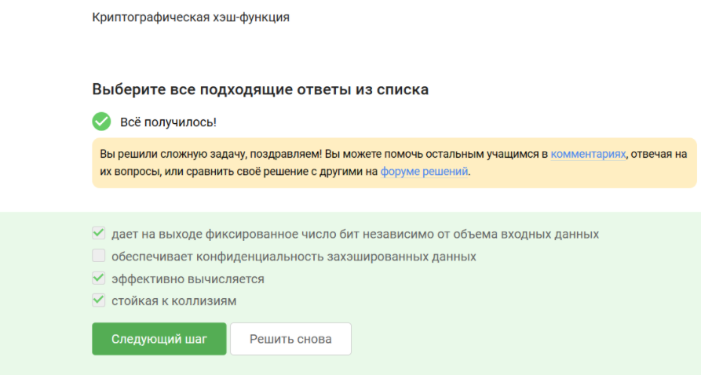

Рисунок 2: Задание 2

## 3

AES и SHA2 не относятся к алгоритмам цифровой подписи (рис. 3)

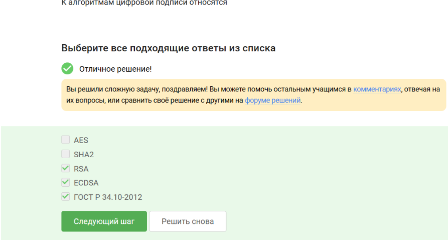

Рисунок 3: Задание 3

## 4

Код аутентификации сообщения-симметричный примитив (рис. 4)

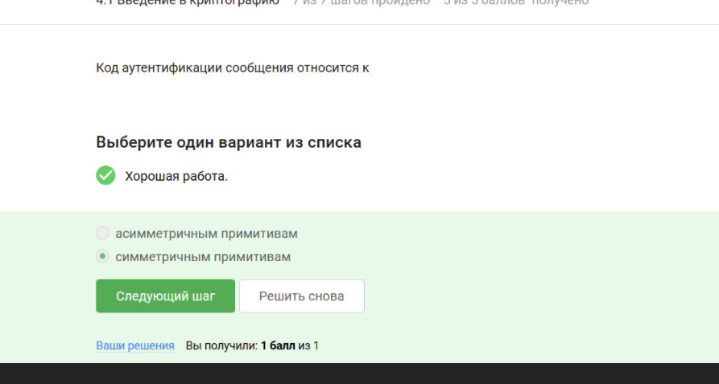

Рисунок 4: Задание 4

## 5

Верное определение обмена ключам Дифии-Хэллмана (рис. 5)

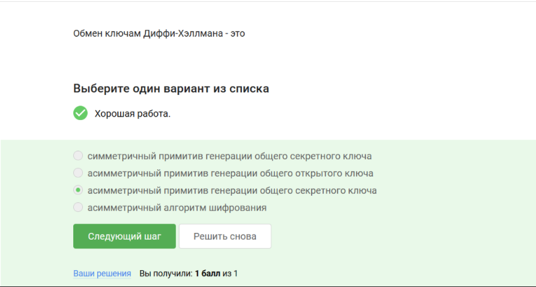

Рисунок 5: Задание 5

## 6

Протокол электронной подписи-протокол с откртым ключом(рис. 6)

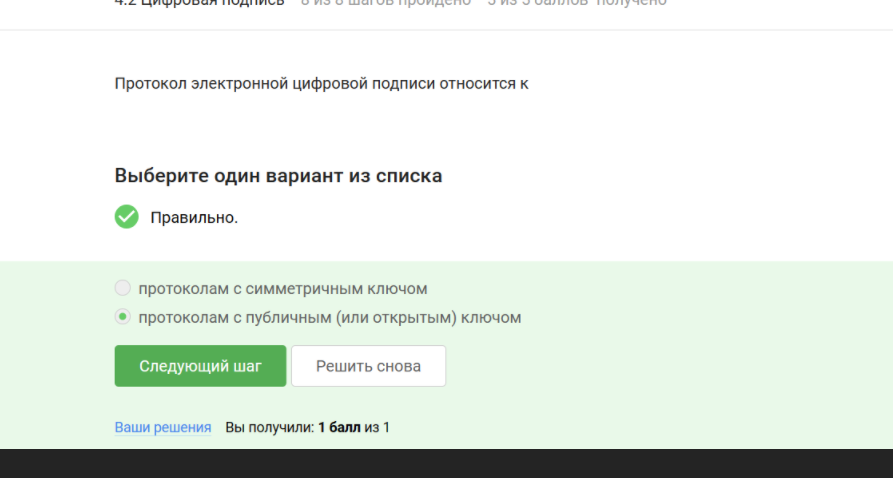

Рисунок 6: Задание 6

## 7

Требуется подпись,откртый ключ, сообщение (рис. 7)

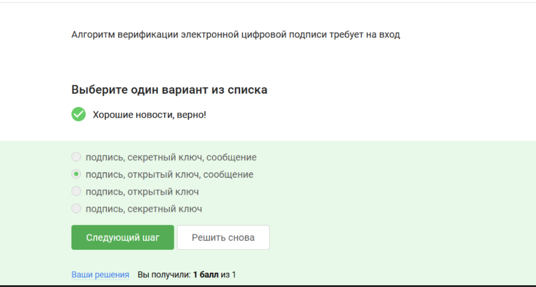

Рисунок 7: Задание 7

## 8

Электронная цифровая подпись не связана с конфиденциальностью (рис. 8)

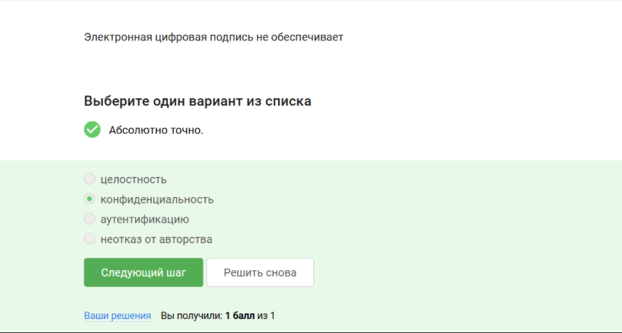

Рисунок 8: Задание 8

## 9

Требуется использовать усиленную квалифицированная электронная подпись для ФНС (рис. 9)

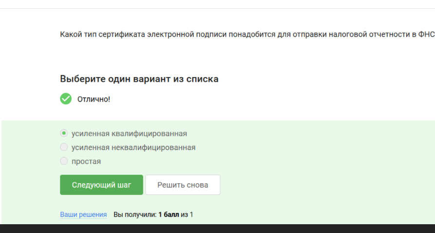

Рисунок 9: Задание 9

## 10

Чертифицированный центр дает сертификат ключа для проверки эл. подписи (рис. 10)

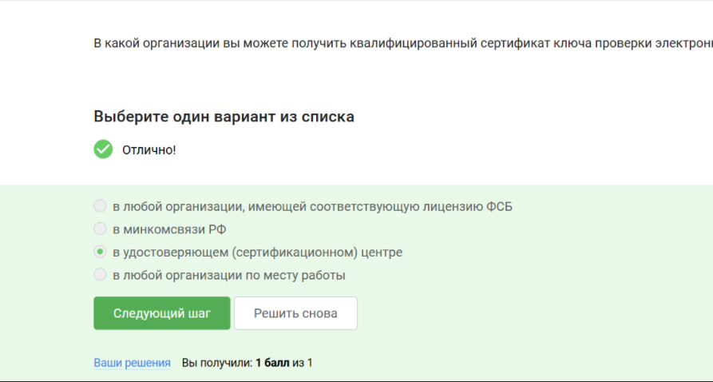

Рисунок 10: Задание 10

## 11

МастерКард и МИР являются платежными системами (рис. 11)

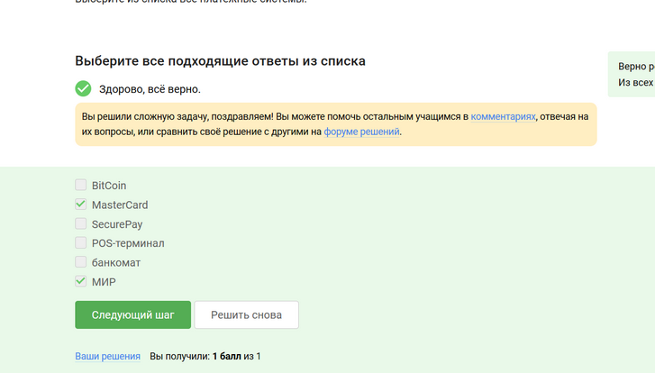

Рисунок 11: Задание 11

## 12

верный ответ на вопрос (рис. 12)

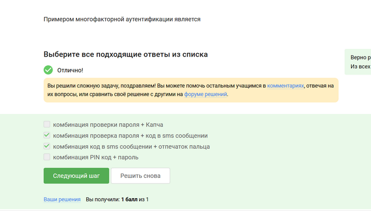

Рисунок 12: Задание 12

## 13

Сногофакторная аутентификация покупателя перед банком-эмитентом используется при онлайн платежах (рис. 13)

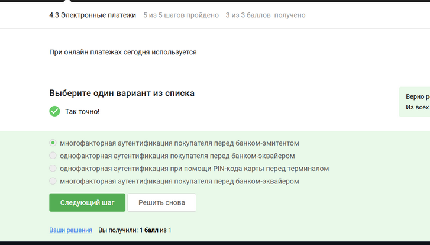

Рисунок 13: Задание 13

## 14

Используется сложность нахождения прообраза(рис. 14)

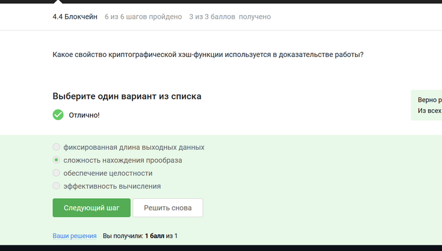

Рисунок 14: Задание 14

## 15

Все ответы верны (рис. 15)

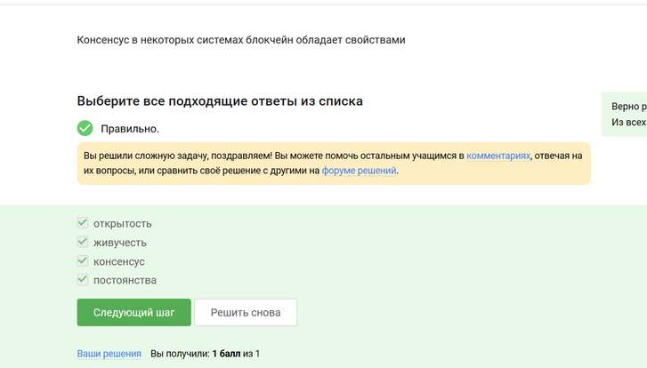

Рисунок 15: Задание 15

## 16

Участники блокчейна хранят секретные ключи цифровой подписи (рис. 16)

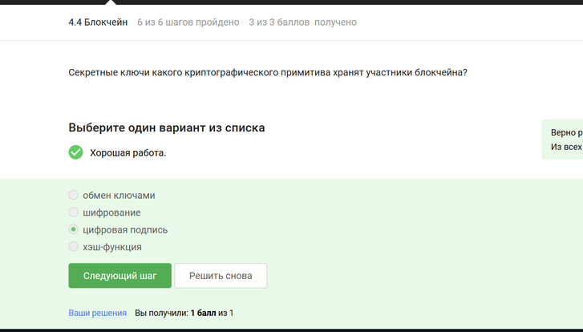

Рисунок 16: Задание 16